# Data Visualization Part 2: Student Project

#### Matriculation Number: 22210364

```python
# Importing all the libraries
import pandas as pd
import matplotlib.pyplot as plt
import numpy as np
from matplotlib.collections import PatchCollection
from matplotlib.gridspec import GridSpec
import matplotlib.cm as cm
```

# Excercise 1

```python
# Importing data for signals
signals = pd.read_csv('10_project_data_signals.csv')

# Displaying the first five observation of the data
signals.head()
```

|  | P1 | P2 | P3 | P4 |
| --- | --- | --- | --- | --- |
| 0 | 0.28 | 0.14 | 0.19 | 0.19 |
| 1 | 0.30 | 0.16 | 0.17 | 0.20 |
| 2 | 0.26 | 0.13 | 0.20 | 0.12 |
| 3 | 0.21 | 0.13 | 0.25 | 0.15 |
| 4 | 0.31 | 0.03 | 0.24 | 0.20 |

```python
# Importing data for annotation
annotation = pd.read_csv('10_project_data_annotation.csv')

# Displaying the first five observation of the data
annotation.head()
```

|  | name | type | start | stop | strand |
| --- | --- | --- | --- | --- | --- |
| 0 | geneA | transcript | 2000 | 7764 | + |
| 1 | geneA | exon | 2700 | 5100 | + |
| 2 | geneA | exon | 6000 | 6800 | + |
| 3 | geneB | transcript | 9000 | 12720 | - |
| 4 | geneB | exon | 9900 | 10100 | - |

## Excersize 1: Version 1:

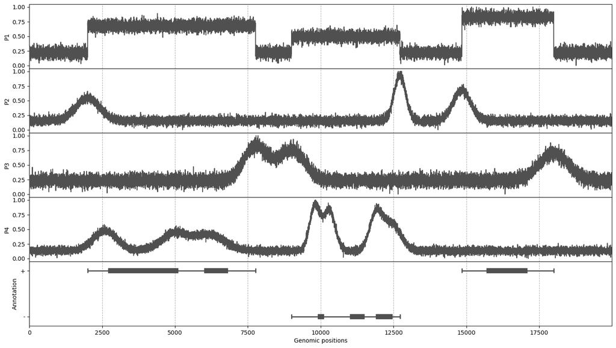

```python
# Creating subplots with 5 rows and 1 column and setting these plots to have one shared x -axis
fig, axs = plt.subplots(5,1, sharex=True)

# Setting up the figure size
fig.set_size_inches(18, 10)

# Setting the verticle space between the plots to be zero
fig.subplots_adjust(hspace=0)

# Drawing the line plots for the 4 columns P1, P2, P3, and P4 in the signals dataset
for i in range(signals.shape[1]):
    # Drawing the line plot
    axs[i].plot(signals.iloc[:, i], color = "#505050", zorder = 5)
    # write the string for labeling y axis
    label = f"P{i + 1}"
    # labeling the y-axis
    axs[i].set_ylabel(label)
    # setting up the ticks for y-axis
    axs[i].set_yticks(np.arange(0, 1.25, 0.25))
    # Setting up the grid for the plot of the style given in the task
    axs[i].grid(True, which='major', axis='x', linestyle='--')
    # limiting the x-axis to particular values
    axs[i].set_xlim([0, signals.shape[0]-1])


# Setting up the plot for drawing the graph for annotation dataset
# limiting the y axis to certain values
axs[4].set_ylim([-0.2, 1.2])

# Giving label to x-axis
axs[4].set_xlabel('Genomic positions')
# Giving label to the y axis of the annotation plot
axs[4].set_ylabel('Annotation')
# Setting up the y ticks to be 0  and 1 only
axs[4].set_yticks([0, 1])
# Changing 0 and 1 to "-" and "+" representing the strands
axs[4].set_yticklabels(["-", "+"])
# Setting up the grid with required style as shown in the task/student project html file
axs[4].grid(True, which='major', axis='x', linestyle='--', zorder = 0)

# Subsetting the annotation file to only give data related to transcripts
df_transcripts = annotation[annotation["type"] == "transcript"]
# Storing the total number of transcripts value in variable to later use in loop
number_of_transcripts = len(df_transcripts)

# Subsetting the annoatation file to only give data related to exons
df_exons = annotation[annotation["type"] == "exon"]
# Storing the total number of exons value in variable to later use in loop
number_of_exons = len(df_exons)

# Creating a dictionary to assocaite number 1 to "+" and 0 to "-" in order to be able to draw lines and rectangle at specific y-axis value
strand_mapping = {'+': 1, '-': 0}

# For loop to draw horziental lines for transcripts and also to have a small verticle line at the ends of the line
for i in range(0, number_of_transcripts):
    # Storing the start position of the line
    start = df_transcripts["start"].iloc[i]
    # Storing the stop position of the line
    stop = df_transcripts["stop"].iloc[i]
    # Getting the strand info from the transcrip dataset
    strand = df_transcripts["strand"].iloc[i]
    # Converting the strand to its associated numerical value
    strand = strand_mapping[strand]

    # Drawing a horizental line for a transcript
    axs[4].hlines(strand, start, stop, color='#505050', linewidth = 2, zorder = 4)
    # Drawing the verticles line at the either end of the transcript line
    axs[4].vlines(start, strand - 0.05, strand + 0.05, color='#505050', linewidth = 2, zorder = 4)
    axs[4].vlines(stop, strand - 0.05, strand + 0.05, color='#505050', linewidth = 2, zorder = 4)

# For loop to draw th rectangle representing the regions where there are exons on the transcript
for i in range (0, number_of_exons):
    # Getting the strand info for the exon
    strand = df_exons["strand"].iloc[i]
    # Converting the strand to its associated numerical value
    strand = strand_mapping[strand]
    # Drawing the rectangle representing
    rectangle = plt.Rectangle((df_exons["start"].iloc[i], strand - 0.05),
                            width = df_exons["stop"].iloc[i] - df_exons["start"].iloc[i] ,
                            height=0.1,
                            facecolor="#505050",
                            edgecolor="#505050", zorder = 4)
    axs[4].add_patch(rectangle)
```

## Excercise 1: Version 2

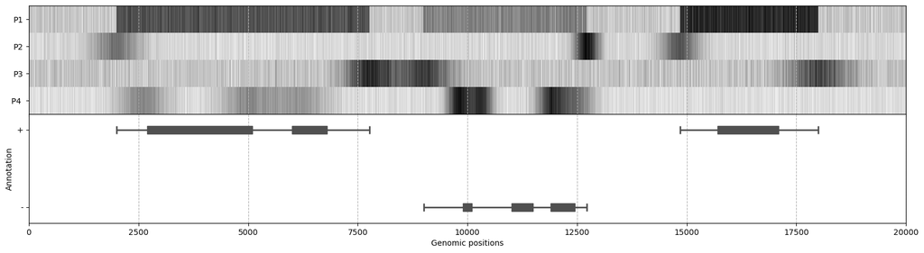

```python
# Creating subplots with 2 rows and 1 column and setting these plots to have one shared x -axis
fig, axs = plt.subplots(2,1, sharex=True)
# Setting up the figure size
fig.set_size_inches(20, 5)
# Setting the verticle space between the plots to be zero
fig.subplots_adjust(hspace=0)

# Getting an array of numbers from zero to total number of observation in signals dataset
x = np.arange(0, signals.shape[0])
# Getting an array reprenting the indexes of the columns in the dataset
y = np.arange(0, signals.shape[1])
# getting the values for color map
c = [signals.P4, signals.P3, signals.P2, signals.P1]

# creating a heatmap with pcolormesh
axs[0].pcolormesh(x, y, c, shading ='nearest', cmap ='gray_r')
# setting up the limit for x-axis
axs[0].set_xlim([0,20000])
# setting up the yticks to contain only required values
axs[0].set_yticks([0, 1, 2, 3])
# changing the values set in the last line to have the labels of the column
axs[0].set_yticklabels(['P4 ', 'P3', 'P2', 'P1'])
# Setting up the grid for the plot
axs[0].grid(True, which='major', axis='x', linestyle='--')

# Setting up the plot for drawing the graph for annotation dataset
# limiting the y axis to certain values
axs[1].set_ylim([-0.2, 1.2])

# Giving label to x-axis
axs[1].set_xlabel('Genomic positions')
# Giving label to the y axis of the annotation plot
axs[1].set_ylabel('Annotation')
# Setting up the y ticks to be 0  and 1 only
axs[1].set_yticks([0, 1])
# Changing 0 and 1 to "-" and "+" representing the strands
axs[1].set_yticklabels(["-", "+"])
# Setting up the grid with required style as shown in the task/student project html file
axs[1].grid(True, which='major', axis='x', linestyle='--', zorder = 0)

# Subsetting the annotation file to only give data related to transcripts
df_transcripts = annotation[annotation["type"] == "transcript"]
# Storing the total number of transcripts value in variable to later use in loop
number_of_transcripts = len(df_transcripts)

# Subsetting the annoatation file to only give data related to exons
df_exons = annotation[annotation["type"] == "exon"]
# Storing the total number of exons value in variable to later use in loop
number_of_exons = len(df_exons)

# Creating a dictionary to assocaite number 1 to "+" and 0 to "-" in order to be able to draw lines and rectangle at specific y-axis value
strand_mapping = {'+': 1, '-': 0}

# For loop to draw horziental lines for transcripts and also to have a small verticle line at the ends of the line
for i in range(0, number_of_transcripts):
    # Storing the start position of the line
    start = df_transcripts["start"].iloc[i]
    # Storing the stop position of the line
    stop = df_transcripts["stop"].iloc[i]
    # Getting the strand info from the transcrip dataset
    strand = df_transcripts["strand"].iloc[i]
    # Converting the strand to its associated numerical value
    strand = strand_mapping[strand]

    # Drawing a horizental line for a transcript
    axs[1].hlines(strand, start, stop, color='#505050', linewidth = 2, zorder = 4)
    # Drawing the verticles line at the either end of the transcript line
    axs[1].vlines(start, strand - 0.05, strand + 0.05, color='#505050', linewidth = 2, zorder = 4)
    axs[1].vlines(stop, strand - 0.05, strand + 0.05, color='#505050', linewidth = 2, zorder = 4)

# For loop to draw th rectangle representing the regions where there are exons on the transcript
for i in range (0, number_of_exons):
    # Getting the strand info for the exon
    strand = df_exons["strand"].iloc[i]
    # Converting the strand to its associated numerical value
    strand = strand_mapping[strand]
    # Drawing the rectangle representing
    rectangle = plt.Rectangle((df_exons["start"].iloc[i], strand - 0.05),
                            width = df_exons["stop"].iloc[i] - df_exons["start"].iloc[i] ,
                            height=0.1,
                            facecolor="#505050",
                            edgecolor="#505050", zorder = 4)
    axs[1].add_patch(rectangle)
```

## Excercise 1: Version 3

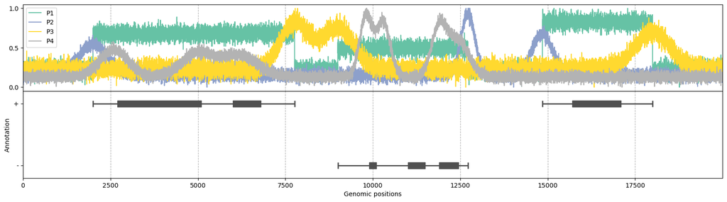

```python
# Creating subplots with 5 rows and 1 column and setting these plots to have one shared x -axis
fig, axs = plt.subplots(2,1, sharex=True)
# Setting up the figure size
fig.set_size_inches(20, 5)
# Setting the verticle space between the plots to be zeor
fig.subplots_adjust(hspace=0)

# Creating a list of colors that would be use to color the lines on the plot
colors = ["#66C2A5", "#8DA0CB", "#FFD92F", "#B3B3B3"]
# Creating a list to label the lines
labels = ["P1", "P2", "P3", "P4"]

# For loop to draw line representing different columns of the signals dataset
for i in range(signals.shape[1]):
    # Drawing the lines with a different color and also labeling the line to later use in legend
    axs[0].plot(signals.iloc[:, i], color = colors[i], label = labels[i])
    axs[0].set_yticks(np.arange(0, 1.25, 0.25))
    axs[0].grid(True, which='major', axis='x', linestyle='--')
    axs[0].legend(loc='upper left')

axs[0].set_xlim([0, signals.shape[0]-1])
axs[0].set_yticks([0,0.5, 1])


df_transcripts = annotation[annotation["type"] == "transcript"]
number_of_transcripts = len(df_transcripts)

# Setting up the plot for drawing the graph for annotation dataset
# limiting the y axis to certain values
axs[1].set_ylim([-0.2, 1.2])

# Giving label to x-axis
axs[1].set_xlabel('Genomic positions')
# Giving label to the y axis of the annotation plot
axs[1].set_ylabel('Annotation')
# Setting up the y ticks to be 0  and 1 only
axs[1].set_yticks([0, 1])
# Changing 0 and 1 to "-" and "+" representing the strands
axs[1].set_yticklabels(["-", "+"])
# Setting up the grid with required style as shown in the task/student project html file
axs[1].grid(True, which='major', axis='x', linestyle='--', zorder = 0)

# Subsetting the annotation file to only give data related to transcripts
df_transcripts = annotation[annotation["type"] == "transcript"]
# Storing the total number of transcripts value in variable to later use in loop
number_of_transcripts = len(df_transcripts)

# Subsetting the annoatation file to only give data related to exons
df_exons = annotation[annotation["type"] == "exon"]
# Storing the total number of exons value in variable to later use in loop
number_of_exons = len(df_exons)

# Creating a dictionary to assocaite number 1 to "+" and 0 to "-" in order to be able to draw lines and rectangle at specific y-axis value
strand_mapping = {'+': 1, '-': 0}

# For loop to draw horziental lines for transcripts and also to have a small verticle line at the ends of the line
for i in range(0, number_of_transcripts):
    # Storing the start position of the line
    start = df_transcripts["start"].iloc[i]
    # Storing the stop position of the line
    stop = df_transcripts["stop"].iloc[i]
    # Getting the strand info from the transcrip dataset
    strand = df_transcripts["strand"].iloc[i]
    # Converting the strand to its associated numerical value
    strand = strand_mapping[strand]

    # Drawing a horizental line for a transcript
    axs[1].hlines(strand, start, stop, color='#505050', linewidth = 2, zorder = 4)
    # Drawing the verticles line at the either end of the transcript line
    axs[1].vlines(start, strand - 0.05, strand + 0.05, color='#505050', linewidth = 2, zorder = 4)
    axs[1].vlines(stop, strand - 0.05, strand + 0.05, color='#505050', linewidth = 2, zorder = 4)

# For loop to draw th rectangle representing the regions where there are exons on the transcript
for i in range (0, number_of_exons):
    # Getting the strand info for the exon
    strand = df_exons["strand"].iloc[i]
    # Converting the strand to its associated numerical value
    strand = strand_mapping[strand]
    # Drawing the rectangle representing
    rectangle = plt.Rectangle((df_exons["start"].iloc[i], strand - 0.05),
                            width = df_exons["stop"].iloc[i] - df_exons["start"].iloc[i] ,
                            height=0.1,
                            facecolor="#505050",
                            edgecolor="#505050", zorder = 4)
    axs[1].add_patch(rectangle)
```

# Discussion:

The pros and cons of differnet visualisation methods are described below

#### Version 1:

Pros:

The version provides a detail information about the individual line and it is a good option if one wants to focus on each line individually.

Cons:

The cons is that the version 1 is not compact and thus not a good option if one wants to compare the different lines to each other

#### Version 2:

Pros:

This version make the graph compact and easy to compare the signal data with one another and also with the annotation data.

Cons:

Although, this plot can be compact and suitable for comparision but it does so by losing information about the individual feature in the signal data. Additionally, the color intensities tries to quantify the differences in the signals but humans are bad at assessing subtle differences in the color which might make this version not a best option.

#### Version 3:

Pros:

This version is probably the best for comparing the signals with one another and with the annotation. The signals are shown with line preserving the information and distinct color used make it clear which signal is representing which.

Cons:

The use of lines for differnt singal in one plot makes the plot cluttered which can make the interpretation of the plot difficult.

# Excercise 2:

```python
# Importing data for scatter plot
df_scatter = pd.read_csv("10_project_data_scatter.csv")
# Showing the first five data of the dataset
df_scatter.head()
```

|  | x1 | x2 |
| --- | --- | --- |
| 0 | 8.41 | 5.43 |
| 1 | 9.56 | 3.92 |
| 2 | 10.83 | 1.80 |
| 3 | 11.14 | 2.32 |
| 4 | 11.41 | 1.41 |

```python
# Importing data for barplot
df_barplot = pd.read_csv("10_project_data_barplot.csv")
# Showing the first five data of dataset
df_barplot.head()
```

|  | Unnamed: 0 | condition_a_sample_1 | condition_a_sample_2 | control |
| --- | --- | --- | --- | --- |
| 0 | XY | 756 | 619 | 689 |
| 1 | XZ | 2411 | 2189 | 782 |
| 2 | YX | 577 | 821 | 689 |
| 3 | YZ | 743 | 781 | 719 |

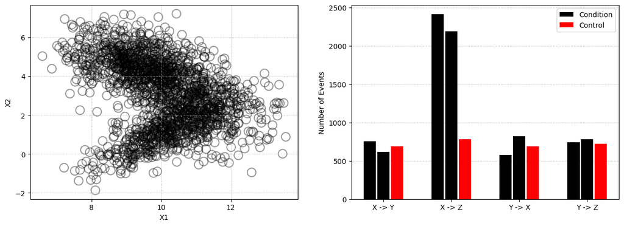

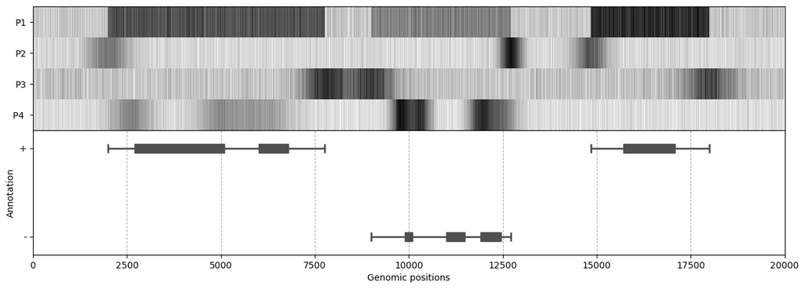

```python
# Creating a figure with constrained layout
fig = plt.figure()
# Setting up size of the figure
fig.set_size_inches(15, 5)
# Creating 1 x 2 grid for subplots
gs = GridSpec(1, 2)

# Creating the first subplot
ax1 = plt.subplot(gs[0, 0])
# Drawing the scatter plot
ax1.scatter(df_scatter.x1, df_scatter.x2, marker = "o", edgecolors="black", facecolors = "none", linewidth = 1.5, alpha = 0.4, s = 150)
# Setting up the xticks with only required values
ax1.set_xticks([8, 10, 12])
# Setting y tickes with only required values
ax1.set_yticks([-2, 0, 2, 4, 6])
# Setting the x label for the plot
ax1.set_xlabel("X1")
# Setting the y label for the plot
ax1.set_ylabel("X2")
# Setting up the grid for the plot
ax1.grid(True, which='major', linestyle='dotted')

# Creating the second subplot
ax2 = plt.subplot(gs[0, 1])
# Defining the postion of the bar
x = np.arange(len(df_barplot))
# Setting up the width of the bars
width_of_bar = 0.18
# Creating a list of colors to color the bar with
colors = ["black", "black", "red"]
# Creating a list that would be used to place the bars for a particular sample with correct distance from each other
bar_position = [-0.2, 0, 0.2]
# Creating a list that stores the labels for the bar
labels = ["Condition", "", "Control"]

# For loop for drawing the bar plot for each condition of each sample
for i in range(len(df_barplot.columns) - 1):
    j = i + 1
    ax2.bar(x + bar_position[i], df_barplot.iloc[:, j], width_of_bar, color = colors[i], label = labels[i], zorder = 5)

# Setting up the xticks, xticklabels, grid, legend and the y axis label
ax2.set_xticks([0, 1, 2, 3])
ax2.set_xticklabels(["X -> Y", "X -> Z", "Y -> X", "Y -> Z"])
ax2.grid(True, which='major', axis='y', linestyle='dotted', zorder = 0)
ax2.legend()
ax2.set_ylabel("Number of Events")

# Creating subplots with 2 rows and 1 column and setting these plots to have one shared x -axis
fig, axs = plt.subplots(2,1, sharex=True)
# Setting up the figure size
fig.set_size_inches(15, 5)
# Setting the verticle space between the plots to be zero
fig.subplots_adjust(hspace=0)

# Getting an array of numbers from zero to total number of observation in signals dataset
x = np.arange(0, signals.shape[0])
# Getting an array reprenting the indexes of the columns in the dataset
y = np.arange(0, signals.shape[1])
# getting the values for color map
c = [signals.P4, signals.P3, signals.P2, signals.P1]

# creating a heatmap with pcolormesh
axs[0].pcolormesh(x, y, c, shading ='nearest', cmap ='gray_r')
# setting up the limit for x-axis
axs[0].set_xlim([0,20000])
# setting up the yticks to contain only required values
axs[0].set_yticks([0, 1, 2, 3])
# changing the values set in the last line to have the labels of the column
axs[0].set_yticklabels(['P4 ', 'P3', 'P2', 'P1'])

# Setting up the plot for drawing the graph for annotation dataset
# limiting the y axis to certain values
axs[1].set_ylim([-0.2, 1.2])

# Giving label to x-axis
axs[1].set_xlabel('Genomic positions')
# Giving label to the y axis of the annotation plot
axs[1].set_ylabel('Annotation')
# Setting up the y ticks to be 0  and 1 only
axs[1].set_yticks([0, 1])
# Changing 0 and 1 to "-" and "+" representing the strands
axs[1].set_yticklabels(["-", "+"])
# Setting up the grid with required style as shown in the task/student project html file
axs[1].grid(True, which='major', axis='x', linestyle='--', zorder = 0)

# Subsetting the annotation file to only give data related to transcripts
df_transcripts = annotation[annotation["type"] == "transcript"]
# Storing the total number of transcripts value in variable to later use in loop
number_of_transcripts = len(df_transcripts)

# Subsetting the annoatation file to only give data related to exons
df_exons = annotation[annotation["type"] == "exon"]
# Storing the total number of exons value in variable to later use in loop
number_of_exons = len(df_exons)

# Creating a dictionary to assocaite number 1 to "+" and 0 to "-" in order to be able to draw lines and rectangle at specific y-axis value
strand_mapping = {'+': 1, '-': 0}

# For loop to draw horziental lines for transcripts and also to have a small verticle line at the ends of the line
for i in range(0, number_of_transcripts):
    # Storing the start position of the line
    start = df_transcripts["start"].iloc[i]
    # Storing the stop position of the line
    stop = df_transcripts["stop"].iloc[i]
    # Getting the strand info from the transcrip dataset
    strand = df_transcripts["strand"].iloc[i]
    # Converting the strand to its associated numerical value
    strand = strand_mapping[strand]

    # Drawing a horizental line for a transcript
    axs[1].hlines(strand, start, stop, color='#505050', linewidth = 2, zorder = 4)
    # Drawing the verticles line at the either end of the transcript line
    axs[1].vlines(start, strand - 0.05, strand + 0.05, color='#505050', linewidth = 2, zorder = 4)
    axs[1].vlines(stop, strand - 0.05, strand + 0.05, color='#505050', linewidth = 2, zorder = 4)

# For loop to draw th rectangle representing the regions where there are exons on the transcript
for i in range (0, number_of_exons):
    # Getting the strand info for the exon
    strand = df_exons["strand"].iloc[i]
    # Converting the strand to its associated numerical value
    strand = strand_mapping[strand]
    # Drawing the rectangle representing
    rectangle = plt.Rectangle((df_exons["start"].iloc[i], strand - 0.05),
                            width = df_exons["stop"].iloc[i] - df_exons["start"].iloc[i] ,
                            height=0.1,
                            facecolor="#505050",
                            edgecolor="#505050", zorder = 4)
    axs[1].add_patch(rectangle)
```

# Excercise 3

```python
# setting up the empty list for sequences
sequences = []

# opening the file having the sequences and appending the sequences to sequences (list)
with open("10_project_data_dna_sequences.txt") as file:
    for line in file:
        sequences.append(line.strip())
```

```python
# setting up a list containing the kmers
kmer_list = ["AA", "AC", "AG", "AT", "CA", "CC", "CG", "CT", "GA", "GC", "GG", "GT", "TA", "TC", "TG", "TT"]

# Creating a dictionary that has kmers as keys and a list of lenght equals to the lenght of sequences and having zero as value at each index
dict_kmer_count = {"AA" : [0] * len(sequences[0]),
                  "AC" : [0] * len(sequences[0]),
                  "AG" : [0] * len(sequences[0]),
                  "AT" : [0] * len(sequences[0]),
                  "CA" : [0] * len(sequences[0]),
                  "CC" : [0] * len(sequences[0]),
                  "CT" : [0] * len(sequences[0]),
                  "CG" : [0] * len(sequences[0]),
                  "TA" : [0] * len(sequences[0]),
                  "TC" : [0] * len(sequences[0]),
                  "TT" : [0] * len(sequences[0]),
                  "TG" : [0] * len(sequences[0]),
                  "GA" : [0] * len(sequences[0]),
                  "GC" : [0] * len(sequences[0]),
                  "GG" : [0] * len(sequences[0]),
                  "GT" : [0] * len(sequences[0])}

# For loop to first pick up a sequence from the sequences list and then transversing through the sequence to find kmer pattern
for i in range(len(sequences)):
    seq = sequences[i]
    for j in range(len(seq)):
        pattern = seq[j:j+2]
        if pattern in kmer_list:
            # increaminting the kmer value at the particular index in which it is found in the sequence by 1
            dict_kmer_count[pattern][j] += 1
```

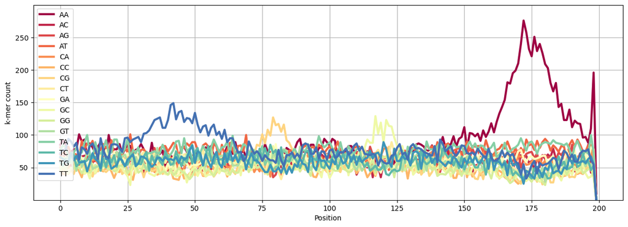

```python
# Creating a 1 x 1 plot
fig , ax = plt.subplots(1,1)

# Setting up the size of the plot
fig.set_size_inches(15, 5)

# Limiting the values of y-axis
ax.set_ylim(0, 300)

# Chosing the color scheme
cmap = cm.Spectral

# For loop to draw a line for each kmer with a distinct color
for i, kmer in enumerate(kmer_list):
    color = cmap(i / len(kmer_list))
    ax.plot(dict_kmer_count[kmer], color=color, label= kmer, linewidth =3)

# moving the legend to upper left corner
ax.legend(loc = "upper left")
# Setting up the grid
ax.grid()
# setting upt y ticks
ax.set_yticks([50, 100, 150, 200, 250])
# Settomg up the x-label
ax.set_xlabel("Position")
# Setting up the y-label
ax.set_ylabel("k-mer count")
```